# Bayesian mixed models with brms | Bayes factor

Last updated: 2021-04-20

## The notorious Bayes Factor

### chapter 7.6 in Lee & Wagenmakers (2014)

## Bayes Factor

- *p*-values have two possible outcomes:
1. reject the null (i.e. \(p<0.05\))
2. inconclusive (i.e. \(p>0.05\) – go back to start)
- BFs have a continuum of three possible outcomes (Dienes, 2014, 2016; Dienes & Mclatchie, 2018):
1. Reject the null / alternative hypothesis
2. Inconclusive (get more data!)
3. Accept the null / alternative hypothesis

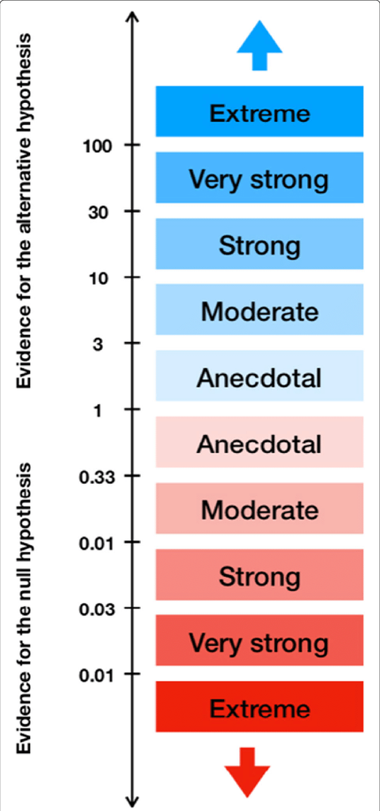

## Bayes Factor

\[ \text{BF} = \frac{p(H_1 \mid y)}{p(H_0 \mid y)} \]

- How much more probable is one model (hypothesis) over the other?
- How convinced should we be about the evidence for our hypothesis \(H_1\) as opposed to, say, a null hypothesis \(H_0\)?
- Savage-Dickey density ratio (Dickey et al., 1970; Jeffreys, 1961):
- Height of the posterior density at zero compared to the height of the prior density at zero.

## Bayes Factor: Savage-Dickey density ratio

\[ \text{BF} = \frac{\text{prior}}{\text{posterior}} \]

- Posterior: \(N(2.5, 1)\)
- Prior: \(N(0,10)\)

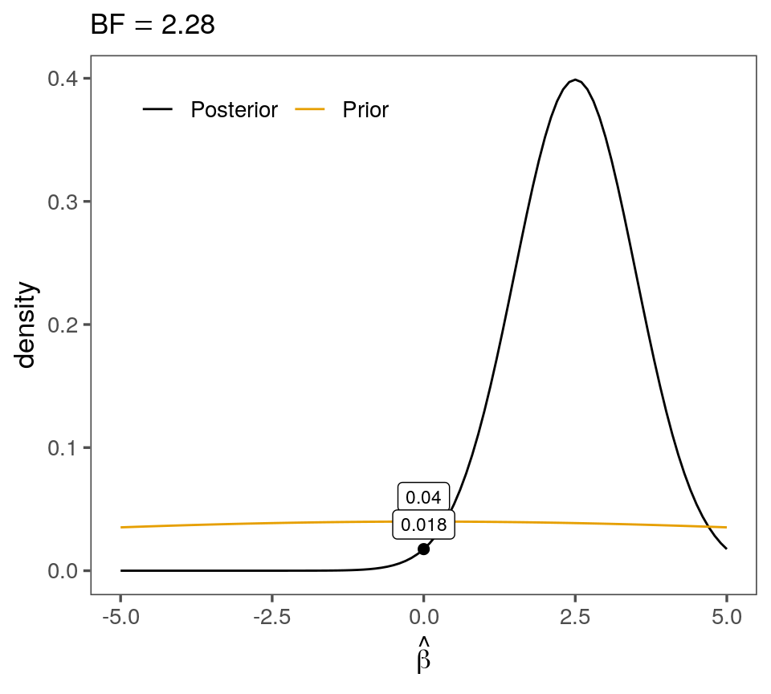

## Bayes Factor: Savage-Dickey density ratio

\[ \text{BF} = \frac{\text{prior}}{\text{posterior}} \]

- Posterior: \(N(2.5, 1)\)
- Prior: \(N(0,5)\)

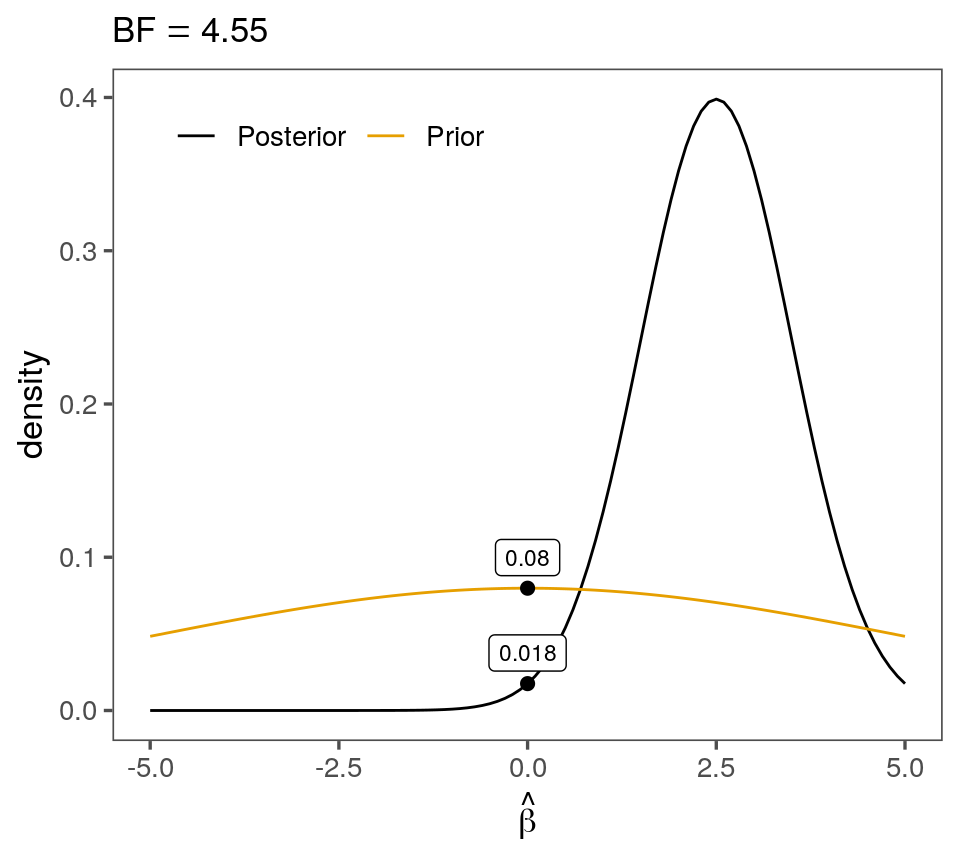

## Bayes Factor: Savage-Dickey density ratio

\[ \text{BF} = \frac{\text{prior}}{\text{posterior}} \]

- Posterior: \(N(2.5, 1)\)
- Prior: \(N(0,2.5)\)

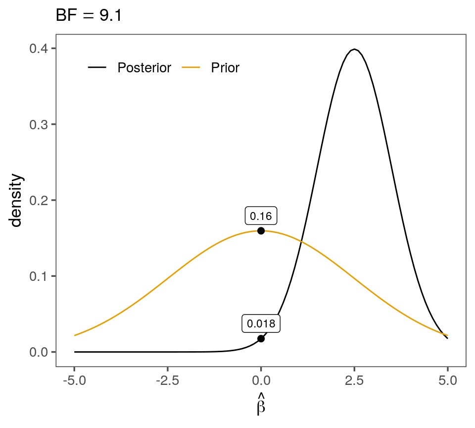

## Bayes Factor: Savage-Dickey density ratio

\[ \text{BF} = \frac{\text{prior}}{\text{posterior}} \]

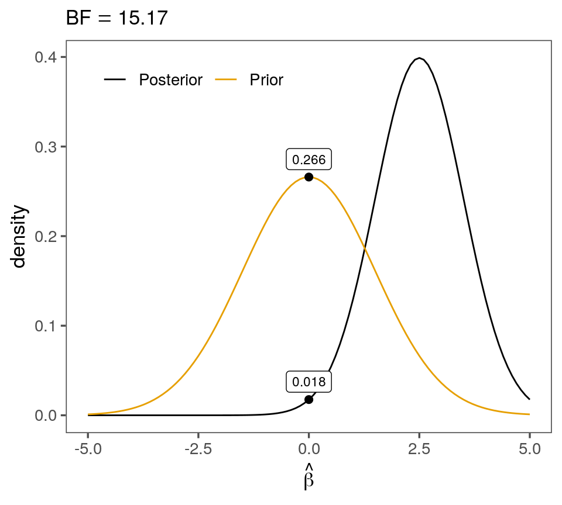

## Bayes Factor

- More informative priors such as \(N(0,1)\) give more weight to \(H_0\).
- Given such a prior, a posterior that favours \(H_1\) would be more convincing: BFs capture this.
- Regularizing (skeptical) priors prevent the model to get overexcited by the sample (his words: McElreath, 2016).

## Bayes Factor

```r
prior <- set_prior("normal(0, 1)", class = "b")
```

```r
fit <- brm(model,
           data = data,
           prior = prior,
           sample_prior = TRUE)
```

- `sample_prior = TRUE` to store the priors that that model used.

## Bayes Factor with `hypothesis()`

```r
# Test whether the posterior supports H0
hypothesis(brms_sim, "conditionb = 0")
```

```
Hypothesis Tests for class b:
        Hypothesis Estimate Est.Error CI.Lower CI.Upper Evid.Ratio Post.Prob
1 (conditionb) = 0    15.54      8.28    -0.15    31.79       1.97      0.66
  Star
1
---
'CI': 90%-CI for one-sided and 95%-CI for two-sided hypotheses.
'*': For one-sided hypotheses, the posterior probability exceeds 95%;
for two-sided hypotheses, the value tested against lies outside the 95%-CI.
Posterior probabilities of point hypotheses assume equal prior probabilities.
```

- Explore `hypothesis()` in the exercise.
- `brms_sim_sample_prior.R`: use `sample_prior = TRUE` and `hypothesis()`
- Bonus: explore the Savage-Dickey method in `bayes_factor.R`

## References

Dickey, J. M., Lientz, B. P., & others. (1970). The weighted likelihood ratio, sharp hypotheses about chances, the order of a markov chain. *The Annals of Mathematical Statistics*, *41*(1), 214–226.

Dienes, Z. (2014). Using Bayes to get the most out of non-significant results. *Frontiers in Psychology*, *5*(781), 1–17.

Dienes, Z. (2016). How Bayes factors change scientific practice. *Journal of Mathematical Psychology*, *72*, 78–89.

Dienes, Z., & Mclatchie, N. (2018). Four reasons to prefer Bayesian analyses over significance testing. *Psychonomic Bulletin & Review*, *25*(1), 207–218.

Jeffreys, H. (1961). *The theory of probability* (Vol. 3). Oxford University Press, Clarendon Press.

Lee, M. D., & Wagenmakers, E.-J. (2014). *Bayesian cognitive modeling: A practical course*. Cambridge University Press.

McElreath, R. (2016). *Statistical rethinking: A Bayesian course with examples in R and Stan*. CRC Press.